# lab

# Part I

Generate 200 random values from the standard exponential distribution and store them in a vector exp.draws.1.

```r
exp.draws.1 <- rexp(n=200)
```

Find the mean and sd

```r
mean(exp.draws.1)
```

```
## [1] 0.991074
```

```r
sd(exp.draws.1)
```

```
## [1] 0.9317983
```

```r
exp.draws.0.1 <- rexp(n=200, rate=.1)
exp.draws.0.5 <- rexp(n=200, rate=.5)
exp.draws.5 <- rexp(n=200, rate=.5)
exp.draws.10 <- rexp(n=200, rate=10)
```

Use the hist() function to produce a histogram of your standard exponential distribution

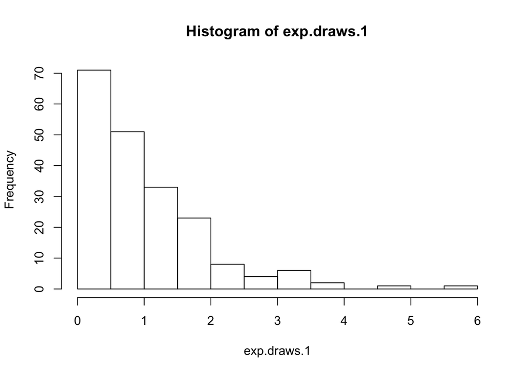

```r
hist(exp.draws.1)
```

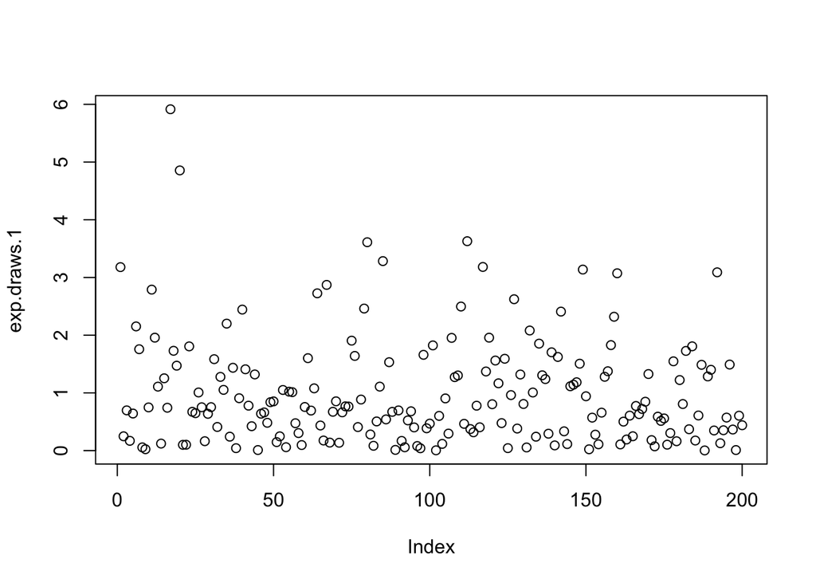

```r
plot(exp.draws.1)
```

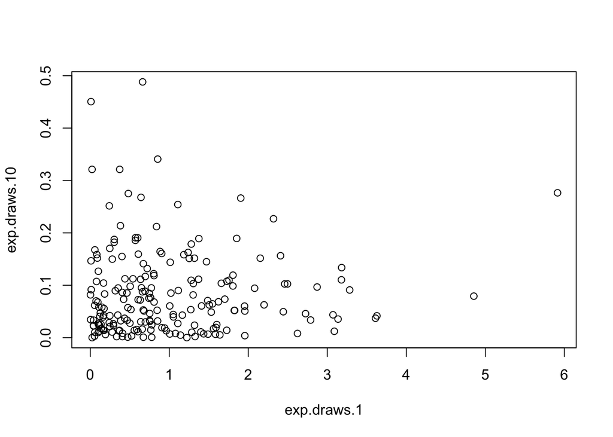

```r
plot(exp.draws.1, exp.draws.10)
```

1. The five means versus the five rates used to generate the distribution.

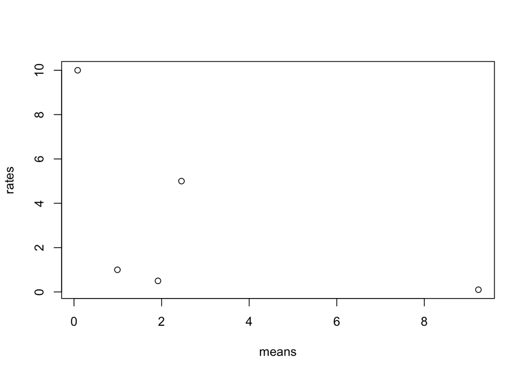

```r
rates = c(.1, .5, 1, 5, 10)
means = c(mean(exp.draws.0.1), mean(exp.draws.0.5), mean(exp.draws.1), mean(exp.draws.5), mean(exp.draws.10))
sds = c(sd(exp.draws.0.1), sd(exp.draws.0.5), sd(exp.draws.1), sd(exp.draws.5), sd(exp.draws.10))


plot(means, rates)
```

b. The standard deviations versus the rates.

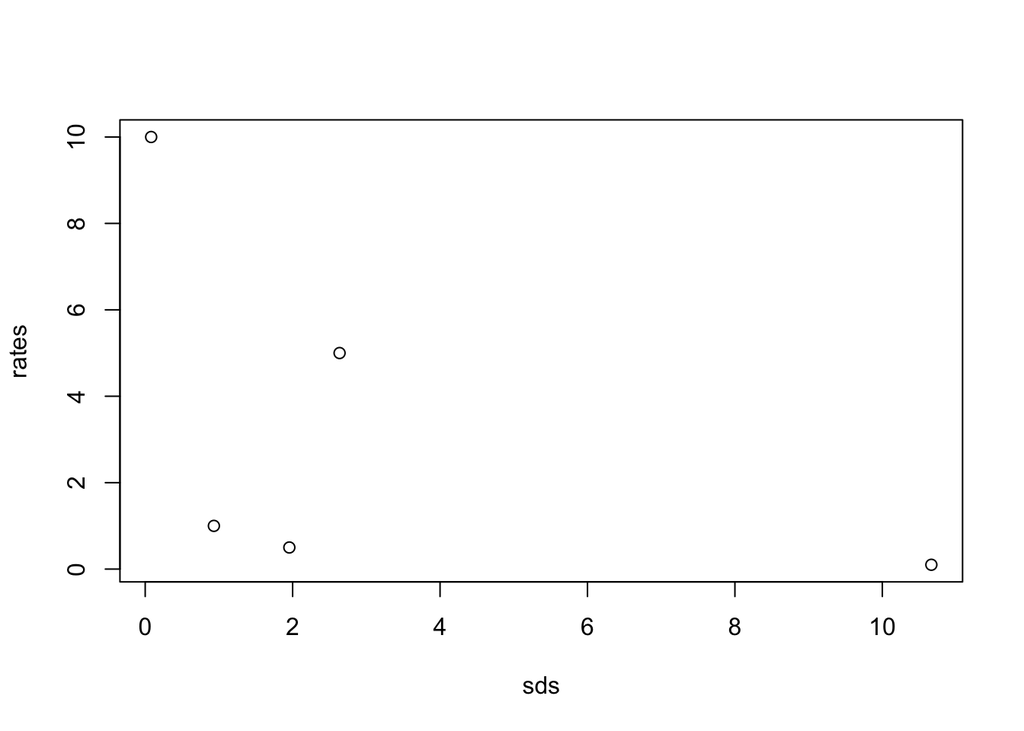

```r
plot(sds, rates)
```

3. The means versus the standard deviations.

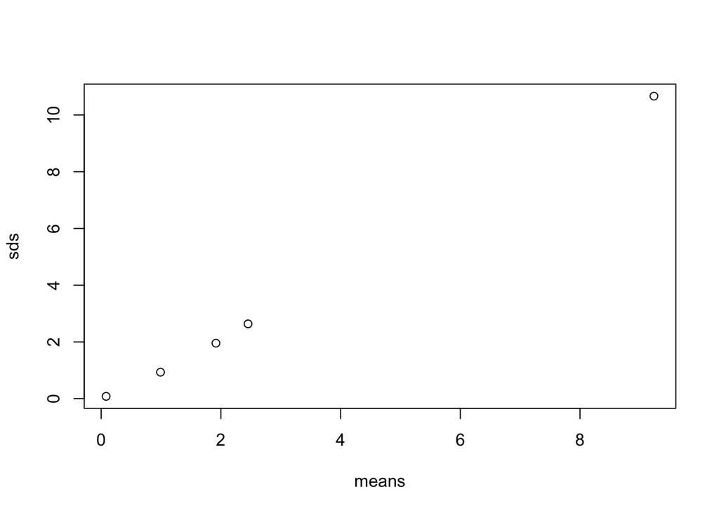

```r
plot(means, sds)
```

# Part II

generate 1.1 million numbers from the standard exponential distribution and store them in a vector called big.exp.draws.1.

```r
draws <- rexp(n=1100000)
mean(draws)
```

```
## [1] 0.9993406
```

```r
sd(draws)
```

```
## [1] 1.000936
```

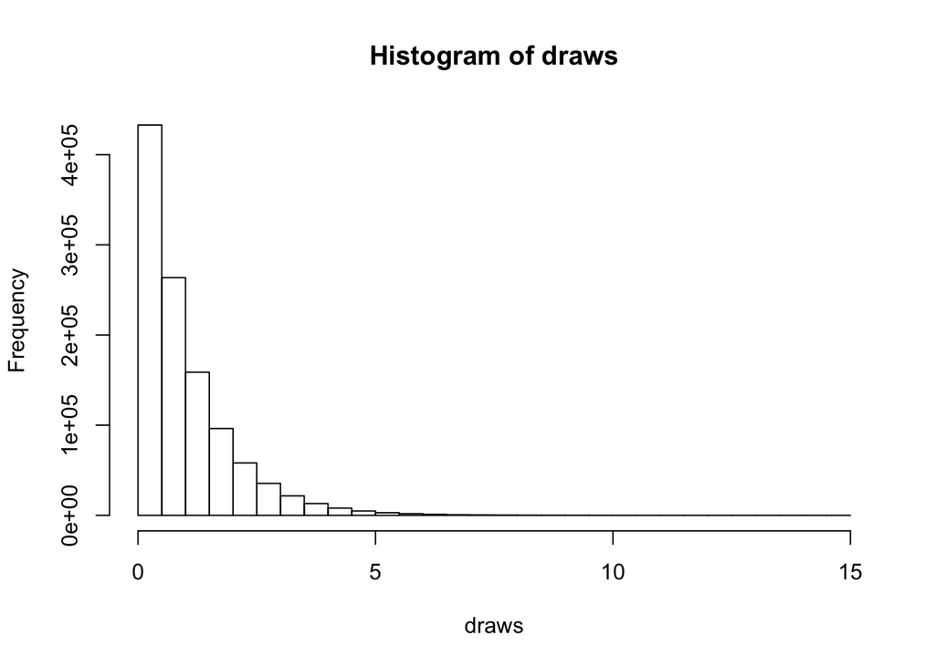

```r
hist(draws)
```

```r
mean(which(draws > 1))
```

```
## [1] 550020.4
```

Create a matrix, big.exp.draws.1.mat, containing the the values in big.exp.draws.1, with 1100 rows and 1000 columns.

```r
mat <- matrix(draws, nrow=1100)
```

Calculate the mean of the 371st column of big.exp.draws.1.mat.

```r
mean(mat[,371])
```

```
## [1] 0.9734211
```

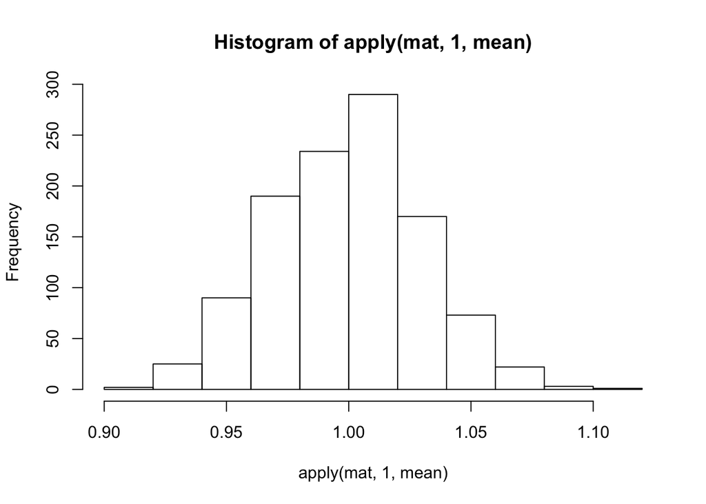

```r
hist(apply(mat, 1, mean))
```

7. Take the square of each number in big.exp.draws.1, and find the mean of this new vector. Explain this in terms of the mean and standard deviation of big.exp.draws.1. Hint: think carefully about the formula R uses to calculate the standard deviation.

```r
mean(draws*draws)
```

```
## [1] 2.000553
```